# Lots of data

S520

July 6, 2016

*Reference: A bit of Trosset chapter 9 but mostly chapter 8*

## Motivation

I take a simple random sample of 100 IU Bloomington faculty (as of 2014) and look up their salaries online. The data is in the file `faculty100.txt`. We can compute the sample average straightforwardly:

```r
salaries = scan("faculty100.txt")
mean(salaries)
```

```
## [1] 91108.09
```

So the mean of this sample of faculty salaries is exactly $91,108.09. But so what?

Another question we can easily answer: what proportion of the sample have salaries of at least $100,000?

```r
sum(salaries >= 100000)
```

```
## [1] 36
```

When we take a **sample**, the usual point is that we don’t just want to draw conclusions about the sample – we want to know about the whole **population**. For example, here we might want to know about the mean salaries of *all* IU Bloomington faculty. We know that the expected value of the sample mean equals the population mean. But to work out to what extent our sample mean is actually useful, we need to answer questions like the following:

1. If we take a large enough sample, are we guaranteed to get the “right” answer?
2. The sample mean is calculated from a random sample, so it’s random, so it has a probability distribution. What is that distribution?
3. If we use the sample mean as an **estimate** of the population mean, how big is the error likely to be?

We usually have to rely on theoretical results rather than getting exact answers to most of these questions, because we don’t know the whole population. Except in this case we do! The file `faculty.txt` includes salaries for all 2478 IU Bloomington faculty salaries. We can thus get theoretical results and then compare then to what we actually see.

## Weak law of large numbers

It’s obvious that if you sample *without* replacement from a finite population, you eventually get the right answer (your sample mean is the same as the population mean) because you eventually sample the entire population. But what if you’re sampling with replacement, or if you’re sampling from an infinite population? In these cases, you’re taking an **independent and identically distributed** (iid) sample.

Let $X_1, \ldots, X_n$ be a sequence of iid random variables with finite mean $\mu$ and finite variance $\sigma^2$. Choose any positive number $\epsilon$. Then as $n \rightarrow \infty$, the probability that the sample mean $\bar{X}_n$ is within $\epsilon$ of the population mean $\mu$ approaches 1:

$$P(\mu - \epsilon < \bar{X}_n < \mu + \epsilon) \rightarrow 1.$$

That is, no matter how small an $\epsilon$ you choose, I can choose a big enough $n$ such that the probability that the sample mean is within $\epsilon$ of the population mean is arbitrarily close to 1.

**Example.** The true mean faculty salary is:

```r
salaries.all = scan("faculty.txt")
mean(salaries.all)
```

```
## [1] 95389.45
```

Suppose we sample with replacement. Can we pick a sample size that’s large enough that we have a very high probability of getting a sample mean within a dollar of the population mean?

Let’s trying a sample size of a million. To take such a sample, use the `sample()` function in R:

```r
x = sample(salaries.all, size=1e6, replace=TRUE)
mean(x)
```

```
## [1] 95400.22
```

Repeat this a few times:

```r
mean(sample(salaries.all, size=1e6, replace=TRUE))
```

```
## [1] 95363.42
```

```r
mean(sample(salaries.all, size=1e6, replace=TRUE))
```

```
## [1] 95435.13
```

```r
mean(sample(salaries.all, size=1e6, replace=TRUE))
```

```
## [1] 95406.8
```

```r
mean(sample(salaries.all, size=1e6, replace=TRUE))
```

```
## [1] 95386.85
```

It seems that a sample size of a million doesn’t guarantee a sample mean within a dollar (or even ten dollars) of the population mean.

Well, let’s try a billion:

```r
mean(sample(salaries.all, size=1e9, replace=TRUE))
```

```
## [1] 95390.51
```

We can use the `replicate()` function to repeat this a few times (independently):

```r
replicate(10, mean(sample(salaries.all, size=1e9, replace=TRUE)))
```

```
##  [1] 95389.27 95388.80 95388.39 95388.60 95390.83 95390.95 95389.59
##  [8] 95390.84 95389.40 95388.78
```

We can see that with reasonable probability, we get within a couple of dollars of the right answer. Similarly, if we upped the sample size to a trillion, we’d be virtually certain of getting the right answer to within a few cents (you might break R by trying to take repeated samples of size one trillion, however.)

So the bad news is that we require prohibitively large samples to get near-exact results. But the good news we rarely care about near exact results. If we want to know the average salary of IU Bloomington faculty, we don’t care about an answer to the nearest dollar – the nearest thousand (or even few thousand) will do.

## The Central Limit Theorem

Roughly: The average of any sufficiently large iid sample has an approximately normal distribution.

Formally: Let $X_1, \ldots, X_n$ be a sequence of iid random variables with finite mean and variance. Let

$$Z_n = \frac{\bar{X}_n - \mu}{\sigma/\sqrt{n}}$$

Then as $n \rightarrow \infty$, the CDF of $Z_n$ converges to the standard normal CDF.

This justifies approximating the distribution of the average of any sufficiently large iid sample by a normal distribution.

The key idea is that the **sample mean** is approximately normal for large samples. (Not the sample itself, which could have whatever distribution.)

Let’s try taking samples from the faculty salaries population and checking for normality. Remember that the `qqnorm()` plot is our main tool for doing this. So we’ll take a sample of size 10, find the sample mean, repeat this a thousand times, and plot the results.

Firstly, look at samples of size 1:

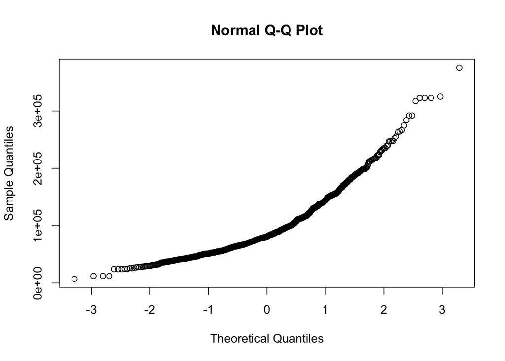

```r
sample.means.1 = replicate(1000, mean(sample(salaries.all, size=1)))
qqnorm(sample.means.1)
```

The mean of a sample of size 1 is just the same as taking a sample of size 1. So the distribution of samples looks the same as the distribution of the population, which is right-skewed and strongly non-normal.

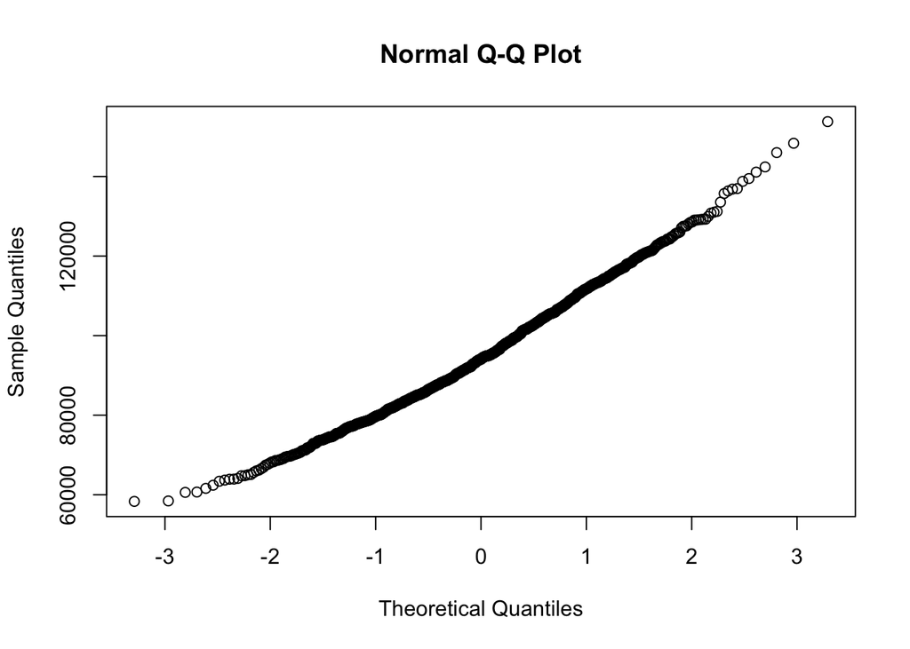

```r
sample.means.10 = replicate(1000, mean(sample(salaries.all, size=10)))
qqnorm(sample.means.10)
```

Even when taking means of samples of size 10, we have to look carefully to see any non-normality. If you look, you’ll notice the line curves upward a little bit. What if we bump the sample size to 100?

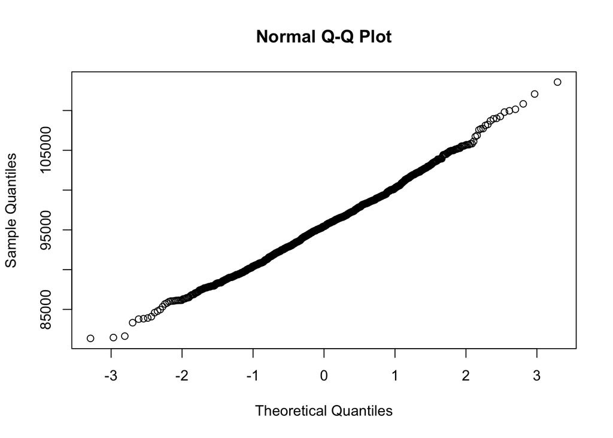

```r
sample.means.100 = replicate(1000, mean(sample(salaries.all, size=100)))
qqnorm(sample.means.100)
```

It’s not absolutely perfectly normal: there’s still a bit of weird stuff going on at the edges. But for practical purposes the normal is a good enough approximation.

## Errors and standard errors

So far we know:

1. The expected value of the sample mean equals the population mean.
2. The distribution of the sample mean is approximately normal for a large sample.

Let the **error** of the sample mean be defined as sample mean minus population mean $(\bar{X} - \mu)$. From 1 and 2, it follows that:

3. For a large sample, the error of the sample mean is approximately normal with mean 0.

Now, to use the normal, we need to know one more thing: the standard deviation of the distribution of the error. We’ll call this the **standard error** of the mean for short. If we knew the population standard deviation was $\sigma$, then from the CLT, the standard error would be $\sigma/\sqrt{n}$, where $n$ is the sample size.

Well, if our sample size is indeed large, a good estimate of the population standard deviation is the sample standard deviation, $s$, which is just the estimate provided by the `sd()` function in R. This adds another layer of approximation, so we restate:

4. For a very large sample, the error of the sample mean is approximately normal with mean 0 and estimated standard error $s/\sqrt{n}$.

We can often do better than this approximation if we know something about the population (e.g. what kind of distribution it follows.) But this result always holds, provided we take a large enough sample.

## Confidence intervals

If we set up a interval of the form

$$\bar{X} \pm q \frac{s}{\sqrt{n}}$$

we can find the chance that the interval contains the true population mean $\mu$ as `pnorm(q) - pnorm(-q)`.

**Example.** Let $q = 1$. Then the interval $\bar{X} \pm q \frac{s}{\sqrt{n}}$ contains $\mu$ with probability `pnorm(1) - pnorm(-1)` $\approx 68\%$.

Now, what if instead of starting with a $q$, we start with a probability of getting an interval that contains the true value? Let’s say we want such a probability $\alpha$. Then we need to find a $q$ such that `pnorm(q) - pnorm(-q)` $= \alpha$. From the definition of quantiles and the symmetry of the normal, this is just

$q$ = `qnorm(1 - alpha/2)`

Why? Then `pnorm(q)` is $1 - \alpha/2$ by definition, `pnorm(-q)` is $\alpha/2$ by symmetry, and `pnorm(q) - pnorm(-q)` is $\alpha$ as required.

**Example.** What does $q$ have to be to get a 95% chance of including the population mean?

```r
qnorm(0.975)
```

```
## [1] 1.959964
```

Round this to 1.96 and memorize it.

We now know how to construct an **interval estimate** (rather than a single-number **point estimate**) for the mean faculty salary based on our original random sample of 100. Take the sample mean and add and subtract 1.96 estimated standard errors.

```r
mean(salaries) - qnorm(0.975) * sd(salaries) / sqrt(length(salaries))
```

```
## [1] 81643.45
```

```r
mean(salaries) + qnorm(0.975) * sd(salaries) / sqrt(length(salaries))
```

```
## [1] 100572.7
```

We get the interval estimate $81,643 to $100,573. As we said earlier, we don’t care about a few dollars (and couldn’t estimate to that accuracy even if we did), so round to $82,000 to $101,000.

The last catch is that it’s not longer straightforward to talk about probability. You can talk about probability before you take the sample, or if you’re talking about a theoretical sample. But once you get a particular sample, that’ll determine a particular interval, and it’ll either contain the true value or it won’t. So we fudge and call it an (approximate) **95% confidence interval**. A 95% confidence interval is an interval estimate constructed in such a way that 95% of the time, you’ll get an interval that contains the true value. That means 5% of the time you’ll be wrong, but that’s statistics.

## Do confidence intervals work?

Let’s do a simulation. (The exact syntax here is beyond the scope of the course.)

```r
faculty.interval = function(n){
  salaries.sample = sample(salaries.all, size=n)
  x.bar = mean(salaries.sample)
  s = sd(salaries.sample)
  lower = x.bar - qnorm(0.975) * s / sqrt(n)
  upper = x.bar + qnorm(0.975) * s / sqrt(n)
  return(c(lower, upper))
}
simulations = replicate(1000, faculty.interval(100))
lower.list = simulations[1,]
upper.list = simulations[2,]
too.low = sum(upper.list < mean(salaries.all))
too.high = sum(lower.list > mean(salaries.all))
just.right = 1000 - too.low - too.high
print(c(too.low, too.high, just.right))
```

```
## [1]  49  20 931
```

It’s a bit lower than 95%, but close. In chapter 10, we’ll learn a method that has closer to the right level of coverage.